# Relatorio

Fabio Firanzi, Heitor Dias, Julia Fideles, Matheus Soares, Tiago Braga

2025-11-11

Tabela 1: Frequência de Presença na Prova de LC

| Status | Percentual (%) | Frequência (N) |
| --- | --- | --- |
| Presente | 73.12 | 316843 |
| Ausente | 26.74 | 115880 |
| Eliminado | 0.13 | 571 |

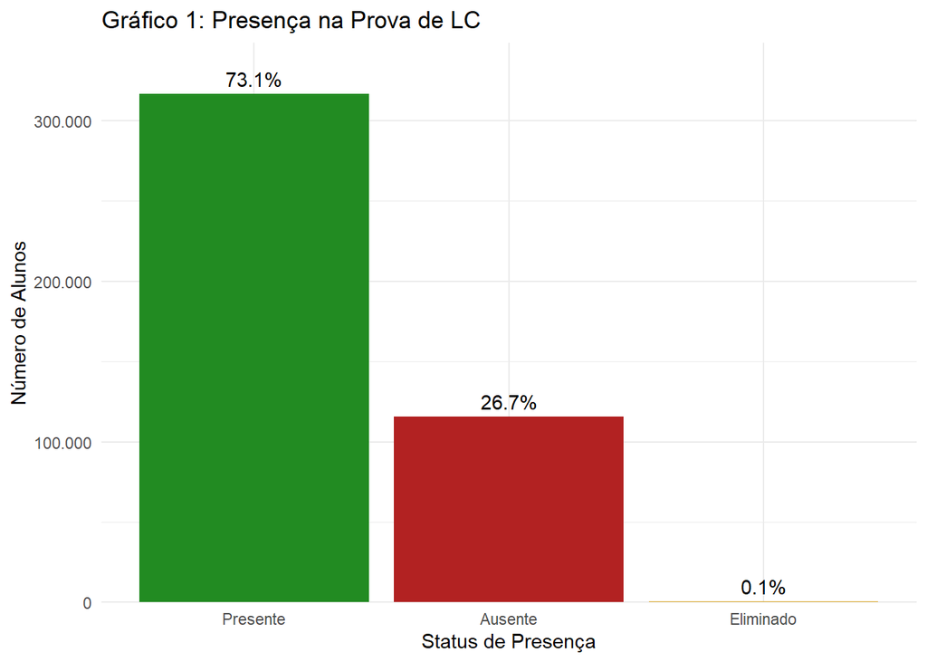

A análise da Tabela 1, que detalha a frequência de presença, revela que a grande maioria, 73,12% dos inscritos realizaram a prova de Linguagens e Códigos, contudo, a taxa de abstenção foi considerável, atingindo 26,74% dos participantes, enquanto uma minoria de 0,13% foi eliminada. Embora a maioria tenha completado a avaliação, o alto índice de ausência sugere a necessidade de estudos futuros para investigar os fatores que contribuem para essa abstenção.

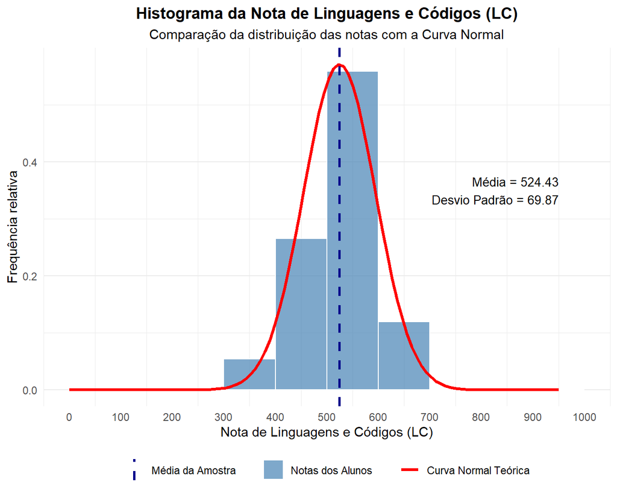

O “Histograma da Nota de LC” ilustra a distribuição de frequência das notas de Linguagens e Códigos para todos os alunos presentes. Ele foi construído sobrepondo uma curva normal teórica (linha vermelha), calculada a partir da média e do desvio padrão da amostra, sobre o histograma das notas reais (barras azuis). A análise visual indica que a distribuição das notas não se ajusta perfeitamente a uma curva normal; há uma concentração maior de alunos com notas na faixa de 500-600 pontos, ligeiramente acima da média (linha tracejada), e a “cauda” de notas altas (acima de 700) é menos pronunciada do que a curva teórica sugeriria.

Tabela Comparativa: LC vs MT (para 298.976 alunos presentes em ambas e com nota > 0)

| Prova | Média | Mediana | Desv. Padrão | Mínimo | Máximo |
| --- | --- | --- | --- | --- | --- |
| Linguagens e Codigos | 526.70 | 533.3 | 68.03 | 298.8 | 795.8 |
| Matematica | 527.24 | 499.1 | 113.91 | 342.8 | 961.9 |

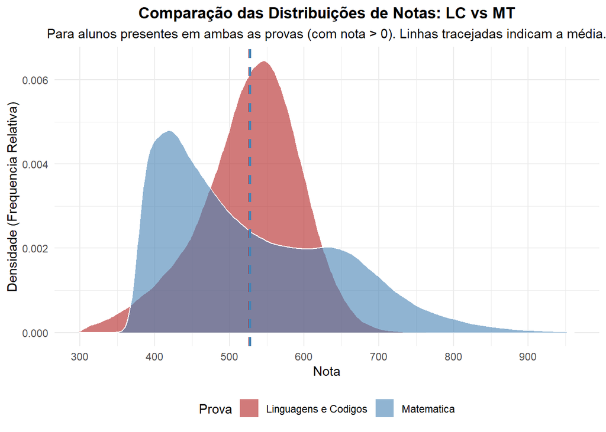

O Gráfico de Densidade oferece uma comparação visual direta entre as distribuições das notas de Linguagens (vermelho) e Matemática (azul). Este gráfico foi gerado utilizando apenas os alunos que compareceram e obtiveram nota maior que zero em ambas as provas. Percebe-se que a curva de Matemática é mais achatada e espalhada (refletindo o maior desvio padrão), indicando que há uma variabilidade muito maior nas notas. Em contraste, as notas de Linguagens são mais “pontudas” e concentradas em torno de sua média.

Tabela Resumo: Estatísticas das Notas de LC por Região

| Região | Média | Mediana | Variância | Desv. Padrão | Mínimo | Máximo | Nº de Alunos |
| --- | --- | --- | --- | --- | --- | --- | --- |
| Sudeste | 542.74 | 548.8 | 3976.62 | 63.06 | 298.8 | 795.8 | 104918 |
| Sul | 540.36 | 545.8 | 3811.32 | 61.74 | 298.8 | 795.8 | 36244 |
| Centro-Oeste | 527.52 | 533.5 | 4542.66 | 67.40 | 298.8 | 777.4 | 24755 |
| Nordeste | 510.60 | 516.3 | 4889.35 | 69.92 | 298.8 | 795.8 | 116314 |
| Norte | 499.47 | 505.4 | 4805.12 | 69.32 | 298.8 | 732.3 | 34406 |

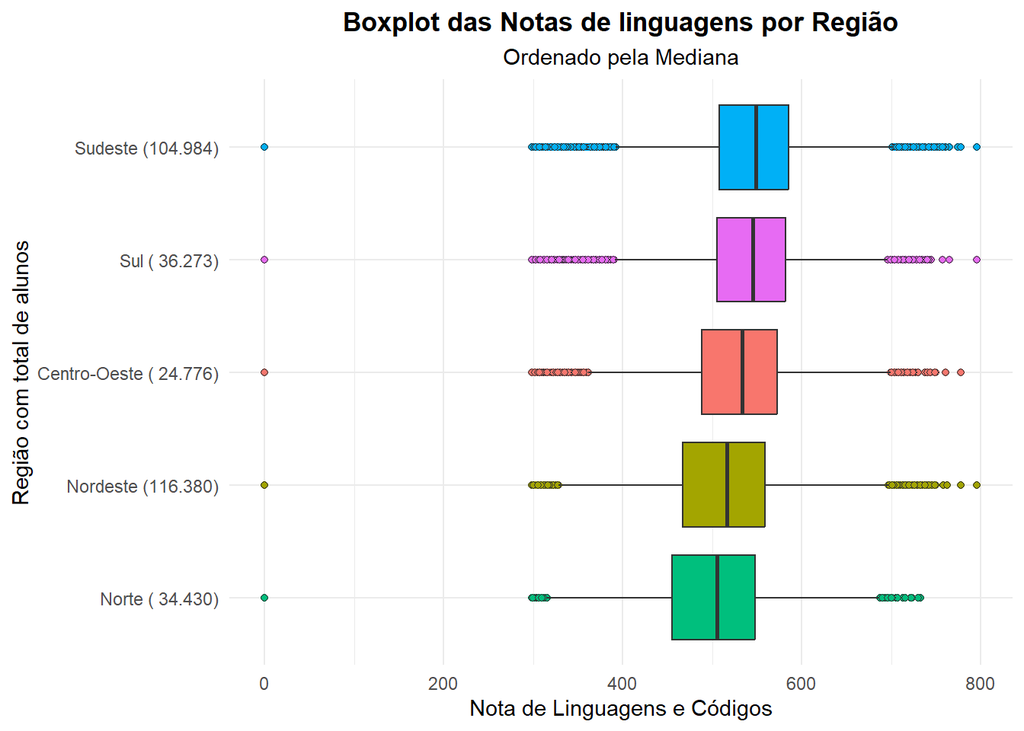

O Boxplot complementa a tabela estatística anterior, visualizando a distribuição das notas de Linguagens e Códigos por região. Ele foi criado agrupando os alunos por região e ordenando o eixo Y pela mediana das notas, da maior para a menor. Este gráfico permite uma visualização clara não apenas da mediana (a linha central na caixa), mas também da dispersão do “meio” dos alunos (o tamanho da caixa, ou Intervalo Interquartil) e dos outliers (pontos). Observa-se que as regiões Sudeste e Sul apresentam as medianas mais elevadas, enquanto as regiões Nordeste e Norte mostram um desempenho mediano inferior e uma dispersão de notas (tamanho da caixa) ligeiramente maior, indicando maior variação no desempenho dos alunos dessas regiões.